# San Francisco Crime Data

M Loecher

Read in sample of SF crime data for 2014

```r
print(load("../data/crimes2014.rda"))#
```

```
## [1] "crimes2014"
```

```r
class(crimes2014$Time)
```

```
## [1] "POSIXct" "POSIXt"
```

```r
head(crimes2014)
```

```
##                      Time      Category
## 49086 2014-09-18 18:00:00     VANDALISM
## 86522 2014-03-20 11:50:00 DRUG/NARCOTIC
## 58161 2014-08-07 14:20:00  NON-CRIMINAL
## 93602 2014-02-17 14:30:00      BURGLARY
## 97896 2014-01-24 00:20:00 LARCENY/THEFT
## 30990 2014-12-13 01:42:00      WARRANTS
##                                                Descript PdDistrict
## 49086                     MALICIOUS MISCHIEF, VANDALISM   RICHMOND
## 86522                             POSSESSION OF OPIATES TENDERLOIN
## 58161                                    FOUND PROPERTY TENDERLOIN
## 93602 BURGLARY,STORE UNDER CONSTRUCTION, UNLAWFUL ENTRY   NORTHERN
## 97896                           GRAND THEFT OF PROPERTY    MISSION
## 30990                   ENROUTE TO OUTSIDE JURISDICTION       PARK
##           Resolution         X        Y violent
## 49086           NONE -122.4789 37.78048   FALSE
## 86522 ARREST, BOOKED -122.4141 37.78279   FALSE
## 58161           NONE -122.4129 37.78383   FALSE
## 93602           NONE -122.4197 37.77803   FALSE
## 97896           NONE -122.4186 37.75463   FALSE
## 30990 ARREST, BOOKED -122.4353 37.76305   FALSE
```

### date/time classes in R

1. How would you compute the *DayOfWeek* from the timestamp? (Hint: check out the library *lubridate*)
2. How would you compute the *HourOfWeek* from the timestamp? What ambiguity needs to be first agreed upon so that you can compare your results to the data given.
3. Compute and graph the integer weekhour pattern of violent crime rate as a barplot. The function *table* will be useful. An example is shown below.

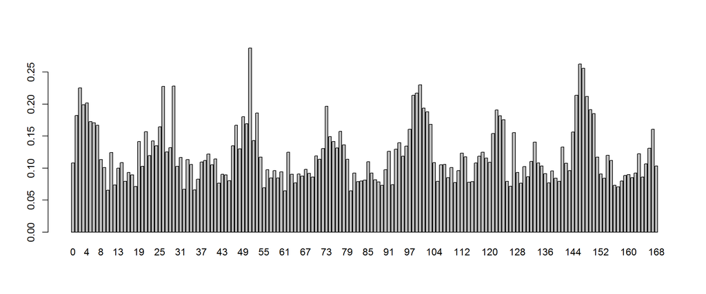

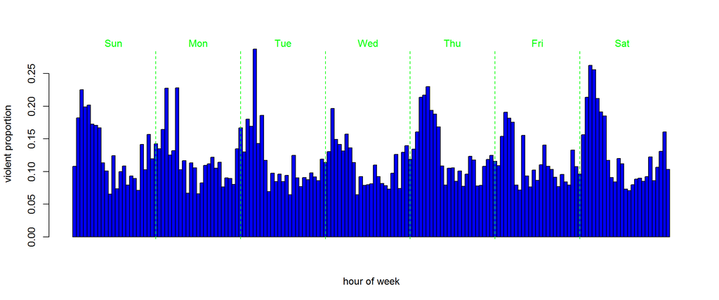

3. Using the commands *table()* and *format()* build an hourly time series of counts of (all) crimes. (Hint: as.POSIXct(“2012-01-02 08”, format=“%Y-%m-%d %H”))
4. Plot that time series.

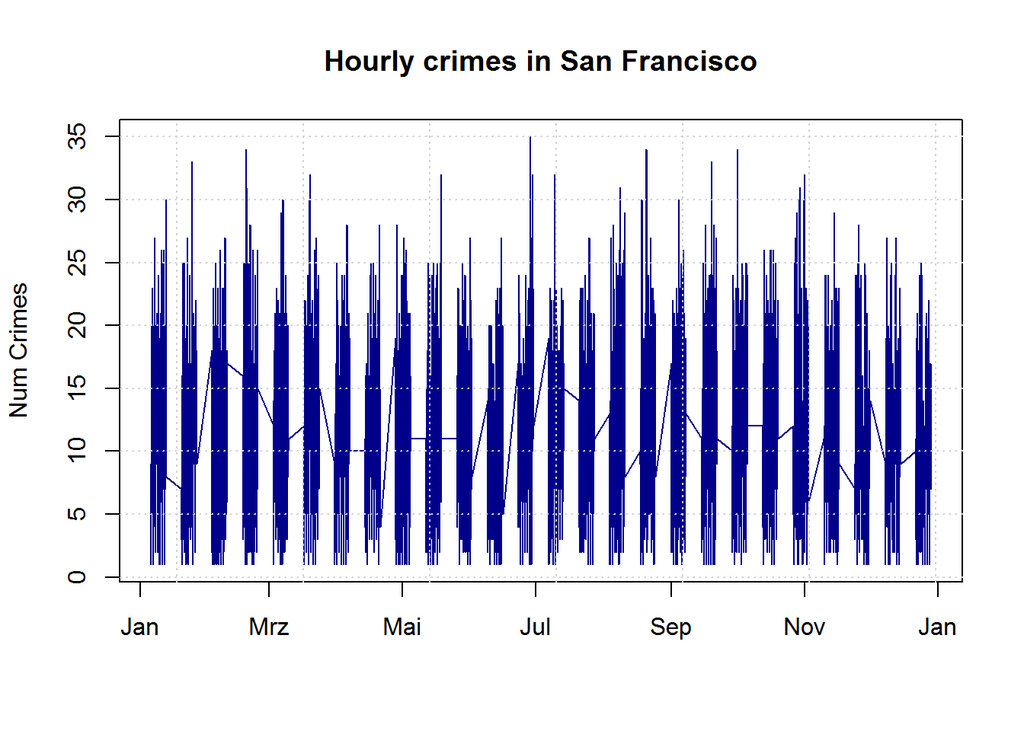

### Interactive Charts

5. Use the package *dygraphs* and look up the documentation at http://rstudio.github.io/dygraphs/ Try to understand the pipe operator %>% and create another interactive time series chart with a range selector!

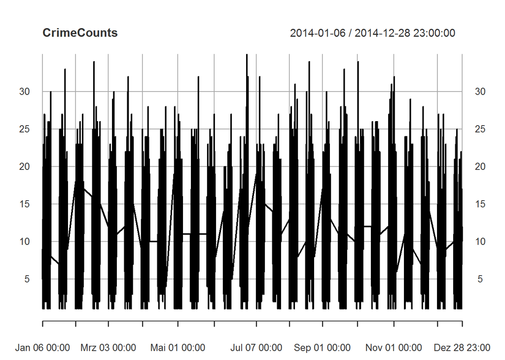

[interactive chart not shown]

6. The * %>% *command is a so called “pipe operator” which is super useful in that it passes the output from one command to another. Simply left to right! In base R we would normally achieve this by chaining functions, e.g. in class we often nest commands such as `round(mean(x),2)`, which in pipe notation would then be written as `mean(x) %>% round(,2)`

# GAMs

Generalized Additive Models to model temporal patterns.

7. Fit a GAM to find the hour-of-day pattern

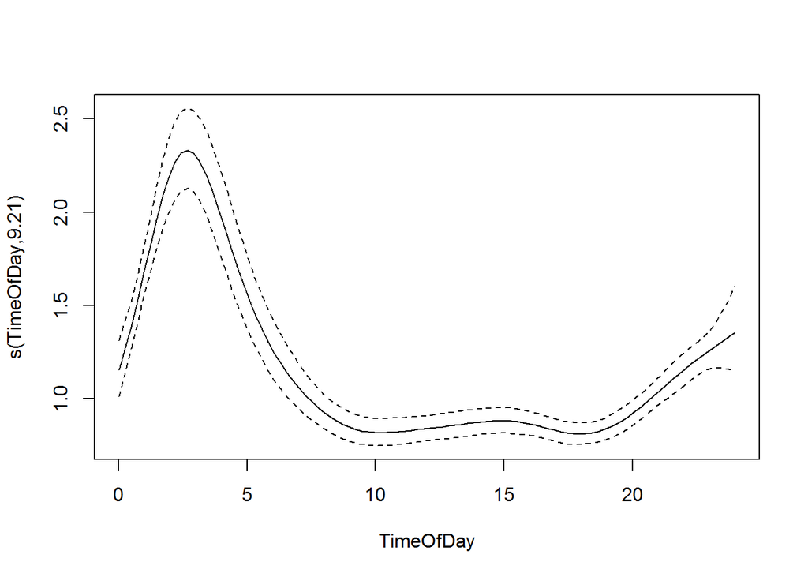

```
##
## Family: binomial
## Link function: logit
##
## Formula:
## violent ~ s(TimeOfDay, k = 12)
##
## Parametric coefficients:
##             Estimate Std. Error z value Pr(>|z|)
## (Intercept)  -2.1143     0.0146  -144.8   <2e-16 ***
## ---
## Signif. codes:  0 '***' 0.001 '**' 0.01 '*' 0.05 '.' 0.1 ' ' 1
##
## Approximate significance of smooth terms:
##                edf Ref.df Chi.sq p-value
## s(TimeOfDay) 9.208  10.33  475.9  <2e-16 ***
## ---
## Signif. codes:  0 '***' 0.001 '**' 0.01 '*' 0.05 '.' 0.1 ' ' 1
##
## R-sq.(adj) =  0.00996   Deviance explained = 1.28%
## UBRE = -0.31307  Scale est. = 1         n = 50000
```

8. Fit a GAM to find the day-of-week pattern
9. Fit a GAM that combines both effects additively
- Do you believe that this would be a sufficiently rich model ?
- How else could you combine the two different periodicities ?
- Look up cyclic spines (periodic boundary conditions) and decide if their implementation makes sense for this case.
- Look up the help function for `bam` and try to speed up your fit.

## Temporal Correlations

11. model the autocorrelation!